# Functionals

This is **Tutorial 4.2** from the ESL course taught at the Faculty of Informatics and Information Technologies, Slovak University of Technology in Bratislava.

The course loosely follows the book *An* *Introduction to Statistical Learning with Applications in R*[^1], while also drawing inspiration from Hadley Wickham’s *Advanced R*[^2]. You may notice small insights borrowed from these two excellent books here and there because they set a remarkably high standard for beginners, and they’re very hard to surpass.

| Version | Last Edit | Changes |
| --- | --- | --- |
| 2026.1 | 15-2-2026 | Minor text edits. |

This optional tutorial introduces you to functional programming and recursion — core ideas for writing elegant, efficient data‑science code in R. It’s not required, but it’s strongly recommended if you want to deepen your understanding and become more effective in R.

### Motivation

In programming, loops and functional constructs serve as tools for iterating over data. Loops, such as *for* and *while*, are imperative constructs that repeatedly execute a block of code until a certain condition is met. They are a staple in procedural programming, allowing for straightforward data manipulation through iteration.

On the other hand, functional programming favors declarative patterns, utilizing functions as the primary means of processing data. This paradigm employs higher-order functions — **functionals** — and recursion instead of traditional loops.

Higher-order functions can take other functions as arguments, return them, or both, enabling a more abstract form of iteration that is less prone to side effects and state mutations. Recursion, another functional approach, involves functions calling themselves with modified parameters until a base condition is satisfied. This method can be more expressive and easier to reason about in terms of mathematical correctness. Functional programming thus promotes immutability and stateless design, which can lead to more predictable and testable code.

As you explore this field, you’ll find that functions are objects, just like any other type of object in R. This allows you to manipulate, combine, and even have functions return other functions. Some differences as these are summarized below, helping you better understand why functional programming is somewhat preferred in data science.

|  | Loops | Functionals |
| --- | --- | --- |
| **Definition** | Loops are control flow structures that repeat a block of code as long as a specified condition is met. | Functionals are higher-order functions that take other functions as arguments and/or return functions as results. |
| **Usage** | They are used for iterating over a sequence (like a list or array) or executing code repeatedly based on a condition. | They are used to apply a function to a collection of items, often replacing explicit loops. |
| **Examples** | Common loops include `for`, `while`, and `do-while` loops. | Common functionals include `map()`, `filter()`, and `reduce()`. |
| **Readability** | Loops can be more intuitive for those familiar with imperative programming, but they can become complex and harder to read with nested or lengthy iterations. | Functionals can make code more concise and readable by abstracting the iteration logic. |
| **Mutability** | Loops often involve mutable state, such as counters or accumulators, which can lead to side effects. | Functionals often work well with immutable data structures, promoting functional programming principles. |
| **Performance** | Loops are generally straightforward and can be very efficient, but they might not benefit from the same level of optimization as functionals in some languages. | In some languages, functionals can be optimized better by the compiler, potentially leading to performance gains. |

### My First Functional `map()`

Most of the functions we’ll discuss are implemented in the **purrr** package, which is part of the **tidyverse**. Among these, the `map()` function serves as a fundamental building block for many other functionals.

The `map()` function is implemented in C for optimal performance, but we can create a simple version in R that achieves the same functionality.

```r
map <- function(x, f, ...) {
  out <- vector("list", length(x))
  for (i in seq_along(x)) {
    out[[i]] <- f(x[[i]], ...)
  }
  out
}
```

At its core, `map()` essentially wraps a common for-loop pattern: it creates a container for the output, applies a function to each element of a list, and fills the container with the results. `map()` takes a list as input and returns a list. Many other for loop functionals follow this same pattern, differing mainly in the types of input or output they handle. Here’s the pictorial representation what `map()` does.

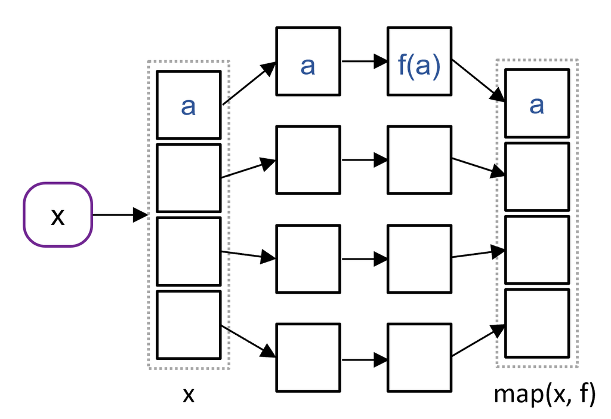

### Vectorized Operations vs. `map()`

R supports vectorized operations, which means functionals are seldom used solely on vectors and lists. However, for demonstration purposes, let’s explore how `map()` can be applied to simple vectors. We’ll calculate the square root of each number in the vector `x`. This can be done by:

- Using `sqrt()` directly on `x` (thanks to R support of vectorized operations),

```r
x <- 1:3
sqrt(x)
```

```
## [1] 1.000000 1.414214 1.732051
```

- Or using functional `map()` together with `sqrt()`.

```r
map_dbl(x, sqrt)
```

```
## [1] 1.000000 1.414214 1.732051
```

The typical usage of `map()` involves specifying the data structure `x` to iterate over and the function `sqrt()` to apply. The `x` should be some type of vector, with lists being the most common.

**Task 1:** Create list `x` consisting of `1`, `2`, `TRUE`, `"Enjoy"` and `NA`. Use `map()` to retrieve the object type of each element in `x`. Transform the resulting list into a character vector.

**Task 2:** Recreate `x` with `c()`. What type and class do you get `x` in? Explain why `x` changed.

### Storing Computed Values in a List

Most of the time, vectorized operations or simple functions are sufficient for vector manipulation. However, functionals excel when you need to perform several tasks simultaneously, such as:

- Create a list.
- Fill the list with the results of a specific calculation.

For example, the code below generates three sets of randomly sampled data from a normal distribution. While this example is simple, the same principle applies to more complex tasks, such as performing cross-validation of a machine learning model using randomly generated subsets of the original data.

In Python, achieving this typically involves multiple steps and several temporary variables. However, with `map()`, you can accomplish the same task in a single line of code.

```r
map(1:3, ~ rnorm(2, mean = 10, sd = 2))
```

In this example, `map()` creates a list with three empty slots (`1:3`), each filling with a vector that has two numbers generated from a normal distribution. The tilde `~` represents a lambda function, which ties the two parts together. You can visualize the processs as such:

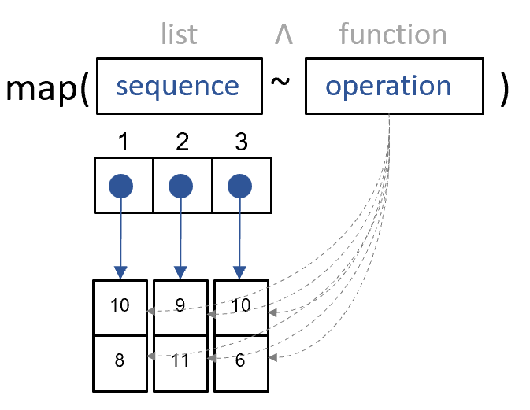

**Task 3:** Combining a list and a lambda function with `map()` is extremely useful for storing computation results. For instance, `map(1:3, ~ runif(2))` effectively stores random numbers generated by `runif(2)`, whereas `map(1:3, runif(2))` does not. Why is that? Can you explain the difference in the results?

### Transforming Data Frames

Using `map()` with data frames is even more intriguing than with vectors and lists. For example, if you want to calculate the average of every skill value of your favorite FIFA players, you could use `summarise()`, but that would involve a lot of repetitive code:

```r
data %>%
  summarise(mean_moves = mean(skill_moves),
            mean_dribbling = mean(skill_dribbling),
            mean_curve = mean(skill_curve),
            ...)
```

Instead, you can apply `mean()` to selected skill coulmns with `map()`.

```r
data %>% head(n=5)
```

```
## # A tibble: 5 × 5
##   short_name        dob        skill_moves skill_dribbling skill_curve
##   <chr>             <date>           <dbl>           <dbl>       <dbl>
## 1 L. Messi          1987-06-24           4              96          93
## 2 R. Lewandowski    1988-08-21           4              85          79
## 3 Cristiano Ronaldo 1985-02-05           5              88          81
## 4 Neymar Jr         1992-02-05           5              95          88
## 5 K. De Bruyne      1991-06-28           4              88          85
```

```r
map(data[,3:5], function(x) mean(x, na.rm = TRUE))
```

```
## $skill_moves
## [1] 2.352461
##
## $skill_dribbling
## [1] 55.66043
##
## $skill_curve
## [1] 47.26893
```

By default, `map()` takes a list and returns a list, which might not be ideal if you’re looking for a human-readable output. Don’t worry, there are ways to address this. For now, you can simply transform the list into a vector using `unlist()`.

```r
unlist(map(data[,3:5], function(x) mean(x, na.rm = TRUE)))
```

```
##     skill_moves skill_dribbling     skill_curve
##        2.352461       55.660429       47.268933
```

Remember, a data frame is essentially a list of columns. `map()` deconstructs this list by extracting each column, applies `mean()` to each numeric vector, and then aggregates the means into a new list. This list is then printed to the console.

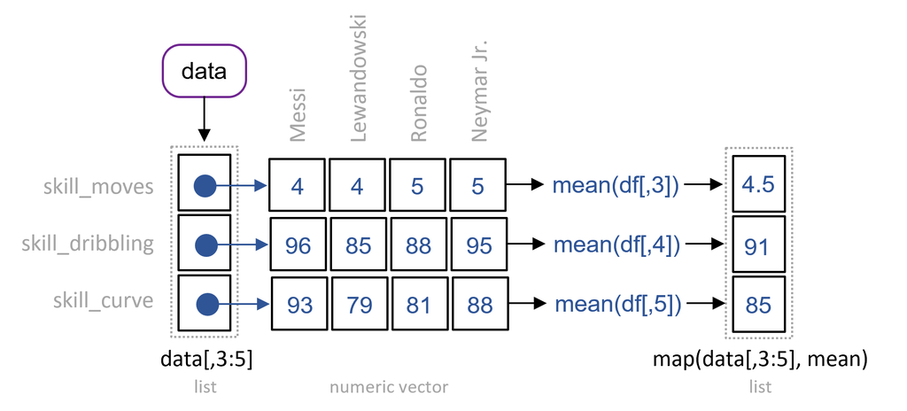

Since `mean()` performs a straightforward operation, the code can function without using lambdas. However, lambdas are essential for more complex computations performed by functionals, or when the data argument in `map()` needs to be placed in a position other than the first in a function call. Nevertheless, this code will work just fine.

```r
map(data[,3:5], mean)
```

### The `reduce()` Family

The reduce family in R contain two functions that are essential for performing operations that involve the progressive reduction of a data structure. For instance, the `reduce()` function takes a binary function and a vector or list as arguments, and it applies the function in an iterative manner to reduce the vector to a single value.

This is particularly useful when the result of an operation on a current element depends on the results of previous elements. A classic example is the cumulative sum, which can be thought of as applying the addition function progressively to a sequence of numbers.

```r
data$skill_dribbling %>% head(n=10) %>% reduce(., sum)
```

```
## [1] 691
```

It’s a concept borrowed from functional programming and is akin to the reduce step in MapReduce, which is used for processing large datasets. While `reduce()` is not intended for big data applications in R, it still remains a crucial tool for data analysis and manipulation within the language.

### Functionals and Infix Functions

In R, the concepts of *infix* and *prefix* functions refer to different ways of defining function parameters. For example, `sum()` is a prefix function, meaning that the function arguments are placed after the function name. Conversely, `+` is an infix function, meaning that the function name is placed between the two arguments it operates on.

**Task 5:** What other infix functions do you know? Name at least 10 of them.

**Task 6:** `reduce()` comes in two flavors. What is the difference between using `sum()` inside `reduce()` compared to `accumulate()`?

**Task 7:** Use `reduce()` to sum all elements in a list of vectors like this.

```r
x <- list(c(1, 2), c(3, 4), c(5, 6))
```

Why do you get a different output when `sum()` is replaced with `+`?

### Footnotes

[^1]: James, Gareth, Daniela Witten, Trevor Hastie, and Robert Tibshirani. 2021. *An Introduction to Statistical Learning: With Applications in R*. 2nd ed. New York: Springer.
[^2]: Wickham, Hadley. 2019. *Advanced R*. 2nd ed. Boca Raton, FL: CRC Press.